# Variable Funktionsparameter

## Variable Funktionsparameter entgegennehmen

Manchmal möchtest du einer Funktion erlauben, eine variable Anzahl an Parametern entgegenzunehmen.

Dafür kannst du die `*` - Schreibweise verwenden, die Parameter landen dann in einem Tupel. Dadurch akzeptiert diese Funktion dann eine variable Anzahl an Parametern:

```python
def calculate_max(*params):
    print(params)
    current_max = params[0]
    for item in params:
        if item > current_max:
            current_max = item
    return current_max

calculate_max(1, 2, 3)
```

```
(1, 2, 3)
```

```
3
```

Zudem hast du die Möglichkeit, über die `**` - Schreibweise mehrere, benannte Parameter entgegen zu nehmen. Diese Parameter landen dann in einem Dictionary, und du kannst aus der Funktion darauf zugreifen:

```python
def f(**args):
    print(args)

f(key="value", key2="Value 2")
```

```
{'key': 'value', 'key2': 'Value 2'}
```

Das beides funktioniert natürlich auch kombiniert. Wichtig ist hierbei, der Parameter mit einem Sternchen (hier: `*params` muss vor dem Parameter mit zwei Sternchen stehen `**args`.

Alle normalen Parameter landen jetzt in dem Tupel `*params`, alle benannten Parameter landen im Dictionary `` `**args ``.

```python
def f(*params, **args):
    print(params)
    print(args)

f("Ein weiterer Wert", "Noch ein Wert", key="value", key2="value2")
```

```
('Ein weiterer Wert', 'Noch ein Wert')
{'key': 'value', 'key2': 'value2'}
```

## Funktion mit Variablen Funktionsparametern aufrufen

Ähnlich wie ein `*` in der Funktionsdefinition mehrere Parameter zusammengefasst hat, können wir auch mehrere Parameter quasi "entpacken".

Hier in dem Fall haben wir eine Liste `l`, und wir möchten, dass das erste Listenelement als Parameter `a` übergeben wird, und das zweite als Parameter `b`:

```python
def f(a, b):
    print(a)
    print(b)

l = [1, 2]
f(*l)
```

```
1
2
```

Gleiches funktioniert natürlich auch für ein Dictionary, hier brauchen wir `**`, um die Parameter zu entpacken:

```python
def f(a, b):
    print(a)
    print(b)

l = {"a": 1, "b": 2}
f(**l)
```

```
1
2
```

### Warum machen wir das?

Manchmal möchten wir Parameter einfach nur "durchschleifen", also gar nicht groß entgegen nehmen, sondern einfach an eine andere Funktion weiterleiten.

Hier im Beispiel werden also Parameter in ein Dictionary gepackt (`**plot_params`, Zeile 4), dadurch können variable Parameter übergeben werden.

Und diese Parameter werden dann in `plt.plot([1, 2, 3], [5, 6, 5], **plot_params)` wieder aus dem Dictionary entpackt, und in normale Funktionsparameter umgewandelt.

So können wir uns z.B. in einen solchen Prozess einklinken.

Beispiel:

```
{'color': 'r', 'linewidth': 10, 'linestyle': 'dashed'}
```

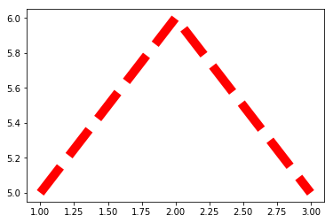

```python
%matplotlib inline
import matplotlib.pyplot as plt

def create_plot(**plot_params):
    print(plot_params)

    plt.plot([1, 2, 3], [5, 6, 5], **plot_params)
    plt.show()

create_plot(color="r", linewidth=10, linestyle="dashed")
```